# Map samples

This script produces a map for all samples included in the study, including number of samples per species.

# Load packages

```r
library(raster)
library(rnaturalearth)
library(sf)
library(adegenet)
library(tidyverse)
library(ggthemes)
library(RStoolbox)
library(scales)
library(broom)
rm(list=ls())
```

# Load and prepare data

Let’s save the names of all species in a vector to facilitate loops.

```r
spp = list.dirs('./input_files/',recursive = F,full.names = F) %>%
  str_extract('^f_.*') %>%
  na.omit() %>%
  str_replace('f_','')

names(spp) = spp
spp
```

```
  Anchylorhynchus     Andranthobius         C_decolor           C_impar          Dialomia
"Anchylorhynchus"   "Andranthobius"       "C_decolor"         "C_impar"        "Dialomia"
        M_bondari         M_ypsilon        P_cocoseae      R_rectinasus
      "M_bondari"       "M_ypsilon"      "P_cocoseae"    "R_rectinasus"
```

We will use the list of bam files used in ANGSD to get sample ids that were effectively included:

```r
insect_specimens = list.files(path = '../ANGSD_weevils/',
                              pattern = '^bam.filelist',
                              recursive = T,
                              full.names = T) %>%
  sapply(function(x){
    readLines(x) %>%
      basename() %>%
      str_remove_all('\\..+$')
  }) %>%
  unlist %>%
  unique
str(insect_specimens)
```

```
 chr [1:336] "BdM1012" "BdM1013" "BdM1014" "BdM1015" "BdM1016" "BdM1017" "BdM1018" ...
```

Let’s do the same with plants:

```r
plant_samples = list.files(file.path('../','ANGSD_plants','coronata_and_botryophora'),
                           pattern = 'bam.filelist',
                           recursive = T,
                           full.names = T) %>%
  file %>%
  readLines() %>%
  basename() %>%
  str_remove_all('\\..+$') %>%
  unique
str(plant_samples)
```

```
 chr [1:74] "BdM1590" "BdM1592" "BdM1594" "BdM1607" "BdM1622" "BdM1637" "BdM1638" ...
```

Now let’s get a count of samples per population for insects. Insect species names in the data table are based on morphology only and not always correspond to the names we will use here, so we will standardize to the names to be used.

```r
name_translation = c('Anchylorhynchus\ntrapezicollis',
                            'Anchylorhynchus\ntrapezicollis',
                            'Andranthobius\nbondari',
                            'Andranthobius\nbondari',
                            'Celetes\ndecolor',
                            'Celetes\nimpar',
                            'Dialomia\npolyphaga',
                            'Microstrates\nbondari',
                            'Microstrates\nypsilon',
                            'Phytotribus\ncocoseae',
                            'Remertus\nrectinasus',
                            'Remertus\nrectinasus')
names(name_translation) = c('Anchylorhynchus botryophorae',
                     'Anchylorhynchus trapezicollis',
                     'Andranthobius bondari',
                     'Andranthobius sp_1',
                     'Celetes decolor',
                     'Celetes impar',
                     'Dialomia sp_1',
                     'Microstrates bondari',
                     'Microstrates ypsilon',
                     'Phytotribus cocoseae',
                     'Remertus sp_1',
                     'Remertus sp_2')
```

We want to map the number of samples per locality, so first we will generate a table with these counts.

```r
insect_df = readr::read_csv('sample_info/sample_data.csv') %>%
  filter(genomics_id %in% insect_specimens) %>% #there are some duplicates, let's remove them
  rowwise() %>%
  mutate(taxon=paste(higher_taxon, species)) %>%
  mutate(taxon=name_translation[taxon]) %>%
  ungroup() %>%
  dplyr::select(taxon,genomics_id,population=pop_id_thesis) %>%
  distinct %>%
  group_by(taxon, population) %>%
  summarise(N = n())
insect_df
```

| taxon | population | N |
| --- | --- | --- |
| Anchylorhynchus\ntrapezicollis | P1 | 6 |
| Anchylorhynchus\ntrapezicollis | P10 | 2 |
| Anchylorhynchus\ntrapezicollis | P11 | 3 |
| Anchylorhynchus\ntrapezicollis | P12 | 2 |
| Anchylorhynchus\ntrapezicollis | P13 | 8 |
| Anchylorhynchus\ntrapezicollis | P15 | 7 |
| Anchylorhynchus\ntrapezicollis | P17_cor | 4 |
| Anchylorhynchus\ntrapezicollis | P17_hyb | 2 |
| Anchylorhynchus\ntrapezicollis | P19 | 1 |
| Anchylorhynchus\ntrapezicollis | P2 | 8 |

[output cut: 88 more lines]

And the same for plants:

```r
plant_df = readr::read_csv('sample_info/Syagrus_data.csv') %>%
  rename(sample = genomics,
         population = pop_id_thesis) %>%
  filter(sample %in% plant_samples) %>%
  dplyr::select(plant_species,sample,lat,lon,population) %>%
  distinct %>%
  group_by(plant_species, population) %>%
  summarise(lat = mean(lat),
          lon = mean(lon),
          N = n()) %>%
  ungroup %>%
  mutate(plant_species = paste('S.',plant_species))
plant_df
```

| plant_species | population | lat | lon | N |
| --- | --- | --- | --- | --- |
| S. botryophora | P1 | -18.354506 | -40.14813 | 5 |
| S. botryophora | P10 | -17.121665 | -39.38133 | 5 |
| S. botryophora | P12 | -13.341591 | -39.19553 | 5 |
| S. botryophora | P3 | -15.307363 | -39.13851 | 5 |
| S. botryophora | P8 | -19.133383 | -40.00009 | 5 |
| S. coronata | P11 | -13.926293 | -40.01776 | 5 |
| S. coronata | P13 | -12.132668 | -38.48499 | 5 |
| S. coronata | P15 | -9.745139 | -36.50992 | 4 |
| S. coronata | P17_cor | -8.931129 | -36.49731 | 1 |
| S. coronata | P19 | -9.740904 | -38.23869 | 5 |

[output cut: 8 more lines]

```r
NA
```

Now let’s put it all in the same data frame:

```r
all_df = plant_df %>%
  dplyr::select(-N) %>%
  right_join(insect_df,by = 'population') %>%
  bind_rows(plant_df %>% mutate(taxon = 'Syagrus'))
all_df
```

| plant_species | population | lat | lon | taxon | N |
| --- | --- | --- | --- | --- | --- |
| S. botryophora | P1 | -18.354506 | -40.14813 | Anchylorhynchus\ntrapezicollis | 6 |
| S. botryophora | P10 | -17.121665 | -39.38133 | Anchylorhynchus\ntrapezicollis | 2 |
| S. coronata | P11 | -13.926293 | -40.01776 | Anchylorhynchus\ntrapezicollis | 3 |
| S. botryophora | P12 | -13.341591 | -39.19553 | Anchylorhynchus\ntrapezicollis | 2 |
| S. coronata | P13 | -12.132668 | -38.48499 | Anchylorhynchus\ntrapezicollis | 8 |
| S. coronata | P15 | -9.745139 | -36.50992 | Anchylorhynchus\ntrapezicollis | 7 |
| S. coronata | P17_cor | -8.931129 | -36.49731 | Anchylorhynchus\ntrapezicollis | 4 |
| S. x costae | P17_hyb | -8.976577 | -36.51690 | Anchylorhynchus\ntrapezicollis | 2 |
| S. coronata | P19 | -9.740904 | -38.23869 | Anchylorhynchus\ntrapezicollis | 1 |
| S. coronata | P2 | -16.150136 | -40.21495 | Anchylorhynchus\ntrapezicollis | 8 |

[output cut: 106 more lines]

# Plot map

Now, let’s download a base map from Natural Earth.

```r
basemap = ne_download(scale = 'large', type = 'GRAY_HR_SR_OB_DR', category = 'raster', destdir = './map')
```

After map is downloaded, let’s crop it to the region of interest:

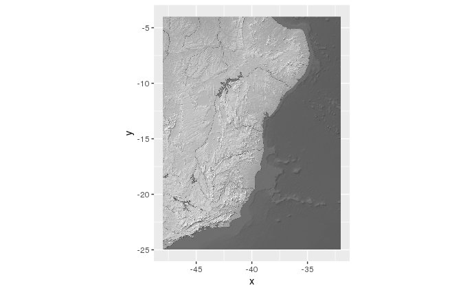

```r
basemap = stack('map/GRAY_HR_SR_OB_DR/GRAY_HR_SR_OB_DR.tif')
bbox = raster::extent(c(xmin=-48,xmax=-32,ymin=-25,ymax=-4))
cropped = raster::crop(basemap,bbox)
map_layer = RStoolbox::ggRGB(cropped, ggLayer = TRUE,r = 1,g=1,b=1)
#the following is just to visualize the layer
print(ggRGB(cropped, r = 1,g=1,b=1))
```

Now let’s plot it all:

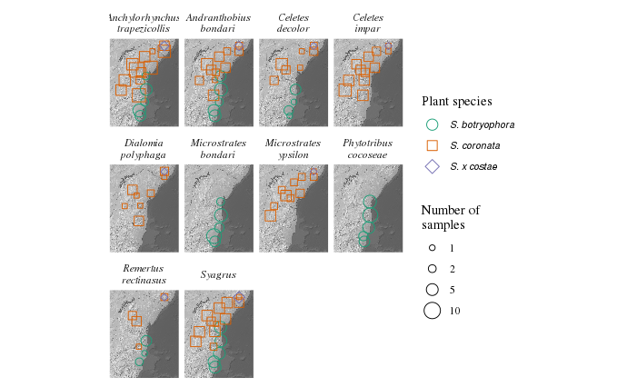

```r
p = ggplot(all_df) +
  map_layer +
  geom_point(aes(x = lon,
                 y = lat,
                 size = N,
                 shape = plant_species,
                 color = plant_species)
  ) +
  scale_shape_manual(values = 21:23,
                     guide = guide_legend(title = 'Plant species',
                                          label.theme = element_text(face='italic',
                                                                     size=8),
                                          override.aes = list(size=4,
                                                              color=c('#1b9e77',
                                                                      '#d95f02',
                                                                      '#7570b3')
                                                              )
                     )) +
  scale_size_area(breaks=c(1,2,5,10),
                        name = 'Number of\nsamples',
                        guide = guide_legend(override.aes = list(shape=21,
                                                                 fill=NA))) +
  scale_color_manual(values = c('S. botryophora' = '#1b9e77',
                                'S. x costae' = '#7570b3',
                                'S. coronata' = '#d95f02'),
                     guide='none') +
  facet_wrap(~taxon,
             ncol=4) +
  theme_tufte() +
  theme(axis.title = element_blank(),
        axis.text = element_blank(),
        axis.ticks = element_blank(),
        strip.text = element_text(face='italic')) +
  coord_equal(xlim = c(-44,-35),
              ylim = c(-8.5,-20))
p
ggsave(filename = 'figures/map_methods.pdf',
       plot = p,
       device = 'pdf',
       width = 168,
       height = 150,
       units = 'mm',
       useDingbats=F)
```

Let’s now plot the map with an inset:

```r
bbox = raster::extent(c(xmin=-44,
              xmax=-35,
              ymin=-20,
              ymax=-8.5)) %>%
  as('SpatialPolygons')
crs(bbox) = crs(basemap)
bbox = st_as_sf(bbox)

cropped_Brazil = raster::crop(basemap,raster::extent(c(xmin=-83,xmax=-33,ymin=-30,ymax=0)))
map_extent_sf = raster::extent(c(xmin=-83,xmax=-33,ymin=-31,ymax=1)) %>%
  as('SpatialPolygons') %>%
  st_as_sf() %>%
  st_set_crs(as.character(crs(cropped_Brazil)))

countries = ne_countries(scale=50, returnclass = 'sf') %>%
  st_transform(as.character(crs(cropped_Brazil))) %>%
  st_intersection(map_extent_sf)
```

```
although coordinates are longitude/latitude, st_intersection assumes that they are planar
```

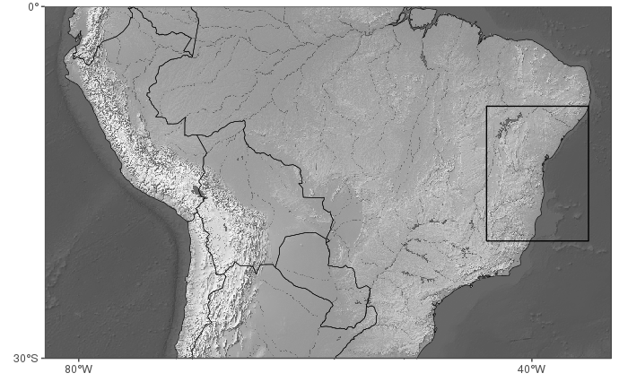

```r
p = ggRGB(cropped_Brazil, r = 1,g=1,b=1) +
  geom_sf(color='black',fill=NA, size=0.2, data=countries) +
  #geom_sf(data=bbox,fill=NA) +
  geom_sf(data=bbox,fill=NA,color='black') +
  coord_sf() +
  theme_few() +
  xlab(NULL) +
  ylab(NULL) +
  scale_x_continuous(expand = c(0,0),
                     breaks=c(-80,-40),limits = c(-83,-33)) +
  scale_y_continuous(expand = c(0,0),
                     breaks=c(0,-30),limits = c(-30,0)) +
  theme(panel.grid = element_blank(),
        plot.background = element_rect(fill = "transparent", color = NA),
        plot.margin = margin(t = 5.5,
                             r = 5.5,
                             b = 5.5,
                             l = 10))
 ggsave(filename = 'figures/map_methods_inset.pdf',
        plot = p,
        device = 'pdf',
        width = 66.6667,
        height = 50,
        units = 'mm',
        useDingbats=F,
        bg="transparent")
print(p)
```